# simu-data-tutorial

# Data Description

This vignette describes how to obtain the graphics in the article presenting the wBHa procedure. Data were produced to compare and evaluate the performance of the different procedures in a GWAS context. For more details on the simulation study and procedures, please refer to the article. The data contained in the simulation_data object group are results obtained from this simulation study. Thus simulation_data is a list containing 390 datasets where :

For the first two cases, 3 scenarios were considered:

- **Scenario 1** corresponds to a situation where rare causal variants have a higher effect than common variants (reference scenario).
- **Scenario 2** corresponds to a situation where common variants have a higher effect than less frequent variants (inverse scenario).
- **Scenario 3** corresponds to a situation where all variants have equal effects (constant scenario).

For these cases (independent and correlation cases), we considered two types of phenotype: quantitative and binary (corresponding to studies for quantitative trait and case-control design).

For the independent case, we considered different values for the total number of null hypotheses tested (size_m), and the number of causal variants (m1) such as:

- size_m $\in$ {8000, 14000, 20000}
- m1 $\in$ {5, 10, 15, 20, 25, 50, 100, 150}

For the correlation case, we considered different values for the number of causal variants (m1), and the correlation values between SNPs (vrho) such as:

- m1 $\in$ {5, 10, 15, 20, 25, 50, 100, 150}
- vrho $\in$ {0.1, 0.2, 0.35, 0.5, 0.75}

Finally, for the semi-simulation, we considered different values for the number of causal variants (m1) such as :

- m1 $\in$ {15, 20, 25, 50, 100, 150}

For each configuration, we simulated 500 datasets, then overall powers and FDRs for each procedure were computed and saved in a data frame (**res_FDR_power**). Moreover, the powers of subgroups for each procedure were computed and saved in a data frame (**res_Subpower**). The subgroups correspond to the 3 distinct subsets of causal variants in which the MAF were generated from the following distributions:

- Group 1 (Rare SNPs): U[0.05,0.15]
- Group 2 (Medium SNPs): U[0.15,0.25]
- Group 3 (Common SNPs): U[0.30,0.40]

From this list (simulation_data), the graphs presented in the article can be made and studied. Below is a tutorial to make them.

# Loading of used libraries

```r
library("ggplot2")
library("cowplot")
library("wBHa")
```

# Functions used

```r
get_legend<-function(myggplot){
  # Allows to extract the legend of the graph "myggplot"
  tmp <- ggplot_gtable(ggplot_build(myggplot))
  leg <- which(sapply(tmp$grobs, function(x) x$name) == "guide-box")
  legend <- tmp$grobs[[leg]]
  return(legend)
}

FDR_graph_design_ind <- function(design_tab,tag){
  # Allows to make FDR graphics of "design_tab"
  # "design_tab" comes from the "simulation_data" of the wBHa package
  # "design_tab" contains the results obtained for the independent case
  graph_FDR_ind <- ggplot(data=design_tab, aes(x=m, y=FDR2, colour=Procedure,shape=Procedure))+
  geom_line(stat="identity",size=0.5)+
    geom_point(size=rep(rep(c(2.5,2,1.75,1.75,2,1.5,1.75,1.75),8),3))+
  scale_shape_manual(values=c(15,16,17,18,19,20,15,17))+
    labs(tag=tag)+
    scale_x_continuous(breaks=c(unique(design_tab$m)),
                       labels=c(as.character(unique(design_tab$m))))+
    geom_hline(yintercept=5, linetype="dashed", color = "red") +
    scale_colour_manual(values=c("#A6CEE3","#1F78B4","#7570B3","#1B9E77",
                                 "#DADAEB","#E69F00","#D9D9D9","#E31A1C"))+
    labs(y=c("FDR (%)")) +
    facet_wrap(~m1,labeller=label_both,scales="free",ncol=4) +
    theme(axis.title.x=element_blank(),
          legend.position="bottom",
          panel.background=element_rect(fill="#F0F0F0", colour="#F0F0F0",
                                        size=0.5, linetype="solid"),
          panel.grid.major=element_line(size=0.5, linetype="solid",
                                        colour="white"),
          panel.grid.minor=element_line(size=0.25, linetype="solid",
                                        colour="white") )

  return(graph_FDR_ind)
}

FDR_graph_design_corr <- function(design_tab,tag){
  # Allows to make FDR graphics of "design_tab"
  # "design_tab" comes from the "simulation_data" of the wBHa package
  # "design_tab" contains the results obtained for the correlation case
  graph_FDR_corr <- ggplot(data=design_tab, aes(x=rho, y=FDR2, colour=Procedure,shape=Procedure))+
  geom_line(stat="identity",size=0.5)+
    geom_point(size=rep(rep(c(2.5,2,1.75,1.75,2,1.5,1.75,1.75),8),5))+
  scale_shape_manual(values=c(15,16,17,18,19,20,15,17))+
    labs(tag=tag)+
    scale_x_continuous(breaks=c(unique(design_tab$rho)),
                       labels=c(as.character(unique(design_tab$rho))))+
    geom_hline(yintercept=5, linetype="dashed", color = "red") +
    scale_colour_manual(values=c("#A6CEE3","#1F78B4","#7570B3","#1B9E77",
                                 "#DADAEB","#E69F00","#D9D9D9","#E31A1C"))+
    labs(y=c("FDR (%)")) +
    facet_wrap(~m1,labeller=label_both,scales="free",ncol=4) +
    theme(axis.title.x=element_blank(),
          legend.position="bottom",
          panel.background=element_rect(fill="#F0F0F0", colour="#F0F0F0",
                                        size=0.5, linetype="solid"),
          panel.grid.major=element_line(size=0.5, linetype="solid",
                                        colour="white"),
          panel.grid.minor=element_line(size=0.25, linetype="solid",
                                        colour="white") )

  return(graph_FDR_corr)
}

power_graph_design_ind <- function(design_tab,tag){
  # Allows to make power graphics of "design_tab"
  # "design_tab" comes from the "simulation_data" of the wBHa package
  # "design_tab" contains the results obtained for the independent case
  graph_power_ind <- ggplot(data=design_tab,aes(x=m, y=Power2, colour=Procedure,shape=Procedure))+
  geom_line(stat="identity",size=0.5)+
    geom_point(size=rep(rep(c(2.5,2,1.75,1.75,2,1.5,1.75,1.75),8),3))+
  scale_shape_manual(values=c(15,16,17,18,19,20,15,17))+
    labs(tag=tag)+
    scale_x_continuous(breaks=c(unique(design_tab$m)),
                       labels=c(as.character(unique(design_tab$m))))+
    scale_colour_manual(values=c("#A6CEE3","#1F78B4","#7570B3","#1B9E77",
                                 "#DADAEB","#E69F00","#D9D9D9","#E31A1C"))+
    labs(y = c("Power (%)")) +
    facet_wrap(~m1,labeller=label_both,scales="free",ncol=4) +

    theme(axis.title.x=element_blank(),
          legend.position="bottom",
          panel.background=element_rect(fill="#F0F0F0", colour="#F0F0F0",
                                        size=0.5, linetype="solid"),
          panel.grid.major=element_line(size=0.5, linetype="solid",
                                        colour="white"),
          panel.grid.minor=element_line(size=0.25, linetype="solid",
                                        colour="white") )

  return(graph_power_ind)
}

power_graph_design_corr <- function(design_tab,tag){
  # Allows to make power graphics of "design_tab"
  # "design_tab" comes from the "simulation_data" of the wBHa package
  # "design_tab" contains the results obtained for the correlation case
  graph_power_corr <- ggplot(data=design_tab,aes(x=rho, y=Power2, colour=Procedure,shape=Procedure))+
  geom_line(stat="identity",size=0.5)+
    geom_point(size=rep(rep(c(2.5,2,1.75,1.75,2,1.5,1.75,1.75),8),5))+
  scale_shape_manual(values=c(15,16,17,18,19,20,15,17))+
    labs(tag=tag)+
    scale_x_continuous(breaks=c(unique(design_tab$rho)),
                       labels=c(as.character(unique(design_tab$rho))))+
    scale_colour_manual(values=c("#A6CEE3","#1F78B4","#7570B3","#1B9E77",
                                 "#DADAEB","#E69F00","#D9D9D9","#E31A1C"))+
    labs(y = c("Power (%)")) +
    facet_wrap(~m1,labeller=label_both,scales="free",ncol=4) +

    theme(axis.title.x=element_blank(),
          legend.position="bottom",
          panel.background=element_rect(fill="#F0F0F0", colour="#F0F0F0",
                                        size=0.5, linetype="solid"),
          panel.grid.major=element_line(size=0.5, linetype="solid",
                                        colour="white"),
          panel.grid.minor=element_line(size=0.25, linetype="solid",
                                        colour="white") )

  return(graph_power_corr)
}

subpower_graph_design_ind <- function(design_tab,tag){
  # Allows to make subpower graphics of "design_tab"
  # "design_tab" comes from the "simulation_data" of the wBHa package
  # "design_tab" contains the results obtained for the independent case
  subpower_graph <- ggplot(data=design_tab, aes(x=m, y=Power2, colour=Procedure,shape=Procedure))+
  geom_line(stat="identity",size=0.5)+
    geom_point(size=rep(rep(c(2.5,2,1.75,1.75,2,1.5,1.75,1.75),8),3))+
  scale_shape_manual(values=c(15,16,17,18,19,20,15,17))+
    labs(tag=tag)+
    labs(y = c("Power (%)")) +
    scale_x_continuous(breaks=c(unique(design_tab$m)),
                       labels=c(as.character(unique(design_tab$m))))+
    scale_colour_manual(values=c("#A6CEE3","#1F78B4","#7570B3","#1B9E77",
                                 "#DADAEB","#E69F00","#D9D9D9","#E31A1C"))+
    facet_wrap(~m1,labeller=label_both,scales="free",ncol=4) +

    theme(axis.title.x=element_blank(),
          legend.position="bottom",
          panel.background=element_rect(fill="#F0F0F0", colour="#F0F0F0",
                                        size=0.5, linetype="solid"),
          panel.grid.major=element_line(size=0.5, linetype="solid",
                                        colour="white"),
          panel.grid.minor=element_line(size=0.25, linetype="solid",
                                        colour="white") )

  return(subpower_graph)
}

subpower_graph_design_corr <- function(design_tab,tag){
  # Allows to make subpower graphics of "design_tab"
  # "design_tab" comes from the "simulation_data" of the wBHa package
  # "design_tab" contains the results obtained for the correlation case
  subpower_graph <- ggplot(data=design_tab, aes(x=rho, y=Power2, colour=Procedure,shape=Procedure))+
  geom_line(stat="identity",size=0.5)+
    geom_point(size=rep(rep(c(2.5,2,1.75,1.75,2,1.5,1.75,1.75),8),5))+
  scale_shape_manual(values=c(15,16,17,18,19,20,15,17))+
    labs(tag=tag)+
    labs(y = c("Power (%)")) +
    scale_x_continuous(breaks=c(unique(design_tab$rho)),
                       labels=c(as.character(unique(design_tab$rho))))+
    scale_colour_manual(values=c("#A6CEE3","#1F78B4","#7570B3","#1B9E77",
                                 "#DADAEB","#E69F00","#D9D9D9","#E31A1C"))+
    facet_wrap(~m1,labeller=label_both,scales="free",ncol=4) +

    theme(axis.title.x=element_blank(),
          legend.position="bottom",
          panel.background=element_rect(fill="#F0F0F0", colour="#F0F0F0",
                                        size=0.5, linetype="solid"),
          panel.grid.major=element_line(size=0.5, linetype="solid",
                                        colour="white"),
          panel.grid.minor=element_line(size=0.25, linetype="solid",
                                        colour="white") )

  return(subpower_graph)
}
```

# Initialization of parameters

```r
data("simulation_data")
size_n <- 2000 #number of individuals
```

# Creation of graphics

```r
for (Case in c("independent","correlation","semisimulation")) {
  if(Case==c("independent")){ #case without correlations between SNPs
    vrho <- 0 #rho value
    blsize <- 0 #bloc size
    r2 <- 0.2 #coefficient of determination
    graph_FDR_ind <- list(reference="", inverse="", constant="")
    graph_power_ind <- list(reference="", inverse="", constant="")
    graph_power_rare_ind <- list(reference="", inverse="", constant="")

    for (scenario in c("reference","inverse","constant")) {

      if(scenario=="reference"){ #corresponding to scenario 1
        binary_beta=c("B_1.8_1.5_1.3_1.rda")
        quantitative_beta=c("B3210.rda")
      }
      if(scenario=="inverse"){ #corresponding to scenario 2
        binary_beta=c("B_1.3_1.5_1.8_1.rda")
        quantitative_beta=c("B1230.rda")
      }
      if(scenario=="constant"){ #corresponding to scenario 3
        binary_beta=c("B_1.5_1.5_1.5_1.rda")
        quantitative_beta=c("B2220.rda")
      }

      quantitative_tab<-list()
      binary_tab<-list()
      quantitative_tab_subgp<-list()
      binary_tab_subgp<-list()

      for (size_m in c(8000,14000,20000)) {
        #size_m is the total number of null hypotheses tested
        for(m1 in c(5,10,15,20,25,50,100,150)){
          #m1 is the number of causal variants
          linear_file_in=paste("Res_LineR","n",size_n,"m",size_m,"m1",m1,"rho",vrho,
                               "tb",blsize,"r2",r2,quantitative_beta,sep="_")
          res_FDR_power <- simulation_data[[linear_file_in]]$res_FDR_power
          res_Subpower <- simulation_data[[linear_file_in]]$res_Subpower
          name_procedures <- c("BH","wBH","wBHa","IHW","qvalue","swfdr",
                               "FDRreg","CAMT")

          # Quantitative dataframe containing power and FDR
          quantitative_tab[[(length(quantitative_tab)+1)]] <- data.frame(
            name_procedures, unlist(c(res_FDR_power[-1,], use.names=F)),
            c(rep(size_m,8)), c(rep(m1,8)), unlist(c(res_FDR_power[1,],
                                                     use.names=F)) )
          colnames(quantitative_tab[[(length(quantitative_tab))]]) <- c("Procedure",
                                                                        "Power","m",
                                                                        "m1","FDR")


          # Quantitative dataframe containing subpower
          colnames(res_Subpower) <- c("X1","X2","X3")
          quantitative_tab_subgp[[(length(quantitative_tab_subgp)+1)]] <- data.frame(
            Procedure=name_procedures,
            Power=c(res_Subpower$X1, res_Subpower$X2, res_Subpower$X3),
            Subgroup=c(rep("Rare", length(res_Subpower[,1])),
                       rep("Medium", length(res_Subpower[,1])),
                       rep("Commun", length(res_Subpower[,1]))),
            m=rep(size_m,24), m1=rep(m1,24) )



          logit_file_in=paste("Res_Logit","n",size_n,"m",size_m,"m1",m1,"rho",vrho,
                              "tb",blsize,binary_beta,sep="_")

          res_FDR_power <- simulation_data[[logit_file_in]]$res_FDR_power
          res_Subpower <- simulation_data[[logit_file_in]]$res_Subpower
          name_procedures<-c("BH","wBH","wBHa","IHW","qvalue","swfdr",
                             "FDRreg","CAMT")

          # Binary dataframe containing power and FDR
          binary_tab[[(length(binary_tab)+1)]]<-data.frame(
            name_procedures, unlist(c(res_FDR_power[-1,],use.names=F)),
            c(rep(size_m,8)), c(rep(m1,8)), unlist(c(res_FDR_power[1,],
                                                     use.names=F)) )
          colnames(binary_tab[[(length(binary_tab))]])<-c("Procedure","Power","m","m1","FDR")

          # Binary dataframe containing subpower
          colnames(res_Subpower) <- c("X1","X2","X3")
          binary_tab_subgp[[(length(binary_tab_subgp)+1)]] <- data.frame(
            Procedure=name_procedures,
            Power=c(res_Subpower$X1, res_Subpower$X2, res_Subpower$X3),
            Subgroup=c(rep("Rare", length(res_Subpower[,1])),
                       rep("Medium", length(res_Subpower[,1])),
                       rep("Commun", length(res_Subpower[,1]))),
            m=rep(size_m,24), m1=rep(m1,24))

        }
      }
      # Final dataframes formatting
      quantitative_tab <- data.frame(Reduce(rbind, quantitative_tab))
      quantitative_tab$FDR2=quantitative_tab$FDR*100
      quantitative_tab$Power2=quantitative_tab$Power*100

      binary_tab <- data.frame(Reduce(rbind, binary_tab))
      binary_tab$FDR2=binary_tab$FDR*100
      binary_tab$Power2=binary_tab$Power*100

      quantitative_tab_subgp <- data.frame(Reduce(rbind, quantitative_tab_subgp))
      quantitative_tab_rare <- subset(quantitative_tab_subgp,
                                      quantitative_tab_subgp$Subgroup=="Rare")
      quantitative_tab_rare$Power2=quantitative_tab_rare$Power*100

      binary_tab_subgp <- data.frame(Reduce(rbind, binary_tab_subgp))
      binary_tab_rare <- subset(binary_tab_subgp,
                                binary_tab_subgp$Subgroup=="Rare")
      binary_tab_rare$Power2=binary_tab_rare$Power*100

      # Creation of FDR graphics for independent case
      FDR_lineR <- FDR_graph_design_ind(quantitative_tab, "A")
      FDR_logit <- FDR_graph_design_ind(binary_tab, "B")
      legende <- get_legend(FDR_lineR)
      FDR_lineR <- FDR_lineR+theme(legend.position="none")
      FDR_logit <- FDR_logit+theme(legend.position="none")
      graph_FDR_ind[[scenario]] <- plot_grid(FDR_lineR, FDR_logit, legende,
                                         ncol=1, rel_heights=c(2.3,2.3,0.5) )

      # Creation of power graphics for independent case
      power_lineR <- power_graph_design_ind(quantitative_tab, "A")
      power_logit <- power_graph_design_ind(binary_tab, "B")
      legende <- get_legend(power_lineR)
      power_lineR <- power_lineR+theme(legend.position="none")
      power_logit <- power_logit+theme(legend.position="none")
      graph_power_ind[[scenario]] <- plot_grid(power_lineR, power_logit, legende,
                                           ncol=1, rel_heights=c(2.3,2.3,0.5) )
```

```r
      # Creation of subpower graphics for independent case
      power_rare_lineR <- subpower_graph_design_ind(quantitative_tab_rare, "A")
      power_rare_logit <- subpower_graph_design_ind(binary_tab_rare, "B")
      legende <- get_legend(power_rare_lineR)
      power_rare_lineR <- power_rare_lineR+theme(legend.position="none")
      power_rare_logit <- power_rare_logit+theme(legend.position="none")
      graph_power_rare_ind[[scenario]] <- plot_grid(power_rare_lineR, power_rare_logit,
                                                legende, ncol=1,
                                                rel_heights=c(2.3,2.3,0.5) )
    }
  }
  if(Case==c("correlation")){ #case with correlations between SNPs
    size_m <- 8000 #total number of null hypotheses tested
    blsize <- 10 #bloc size
    r2 <- 0.2 #coefficient of determination

    graph_FDR_corr <- list(reference="", inverse="", constant="")
    graph_power_corr <- list(reference="", inverse="", constant="")
    graph_power_rare_corr <- list(reference="", inverse="", constant="")

    for (scenario in c("reference","inverse","constant")) {
      if(scenario=="reference"){ #corresponding to scenario 1
        binary_beta=c("B_1.8_1.5_1.3_1.rda")
        quantitative_beta=c("B3210.rda")
      }
      if(scenario=="inverse"){ #corresponding to scenario 2
        binary_beta=c("B_1.3_1.5_1.8_1.rda")
        quantitative_beta=c("B1230.rda")
      }
      if(scenario=="constant"){ #corresponding to scenario 3
        binary_beta=c("B_1.5_1.5_1.5_1.rda")
        quantitative_beta=c("B2220.rda")
      }

      quantitative_tab<-list()
      binary_tab<-list()
      quantitative_tab_subgp<-list()
      binary_tab_subgp<-list()
      for(m1 in c(5,10,15,20,25,50,100,150)){
        #m1 is the number of causal variants
        for (vrho in c(0.10,0.20,0.35,0.5,0.75)) {
          #vrho is the correlation value between variants
          linear_file_in <- paste("Res_LineR","n",size_n,"m",size_m,"m1",m1,
                                  "rho",vrho,"tb",blsize,"r2",r2,
                                  quantitative_beta,sep="_")
          res_FDR_power <- simulation_data[[linear_file_in]]$res_FDR_power
          res_Subpower <- simulation_data[[linear_file_in]]$res_Subpower
          name_procedures <- c("BH","wBH","wBHa","IHW","qvalue","swfdr",
                               "FDRreg","CAMT")

          # Quantitative dataframe containing power and FDR
          quantitative_tab[[(length(quantitative_tab)+1)]] <- data.frame(
            name_procedures, unlist(c(res_FDR_power[-1,],use.names=F)),
            c(rep(vrho,8)), c(rep(m1,8)), unlist(c(res_FDR_power[1,],use.names=F)))
          colnames(quantitative_tab[[(length(quantitative_tab))]]) <- c("Procedure",
                                                                        "Power","rho",
                                                                        "m1","FDR")

          # Quantitative dataframe containing subpower
          colnames(res_Subpower) <- c("X1","X2","X3")
          quantitative_tab_subgp[[(length(quantitative_tab_subgp)+1)]] <- data.frame(
            Procedure=name_procedures,
            Power=c(res_Subpower$X1, res_Subpower$X2, res_Subpower$X3),
            Subgroup=c(rep("Rare", length(res_Subpower[,1])),
                       rep("Medium", length(res_Subpower[,1])),
                       rep("Commun", length(res_Subpower[,1]))),
            rho=rep(vrho,24), m1=rep(m1,24))

          logit_file_in <- paste("Res_Logit","n",size_n,"m",size_m,"m1",m1,
                                 "rho",vrho,"tb",blsize,binary_beta,sep="_")

          res_FDR_power <- simulation_data[[logit_file_in]]$res_FDR_power
          res_Subpower <- simulation_data[[logit_file_in]]$res_Subpower
          name_procedures <- c("BH","wBH","wBHa","IHW","qvalue","swfdr",
                               "FDRreg","CAMT")

          # Binary dataframe containing power and FDR
          binary_tab[[(length(binary_tab)+1)]] <- data.frame(
            name_procedures,unlist(c(res_FDR_power[-1,],use.names=F)),
            c(rep(vrho,8)), c(rep(m1,8)), unlist(c(res_FDR_power[1,],use.names=F)))
          colnames(binary_tab[[(length(binary_tab))]]) <- c("Procedure","Power",
                                                            "rho","m1","FDR")

          # Binary dataframe containing subpower
          colnames(res_Subpower) <- c("X1","X2","X3")
          binary_tab_subgp[[(length(binary_tab_subgp)+1)]] <- data.frame(
            Procedure=name_procedures,
            Power=c(res_Subpower$X1, res_Subpower$X2, res_Subpower$X3),
            Subgroup=c(rep("Rare", length(res_Subpower[,1])),
                       rep("Medium", length(res_Subpower[,1])),
                       rep("Commun", length(res_Subpower[,1]))),
            rho=rep(vrho,24), m1=rep(m1,24))
        }
      }
      # Final dataframes formatting
      quantitative_tab <- data.frame(Reduce(rbind, quantitative_tab))
      quantitative_tab$FDR2=quantitative_tab$FDR*100
      quantitative_tab$Power2=quantitative_tab$Power*100

      binary_tab <- data.frame(Reduce(rbind, binary_tab))
      binary_tab$FDR2=binary_tab$FDR*100
      binary_tab$Power2=binary_tab$Power*100

      quantitative_tab_subgp <- data.frame(Reduce(rbind, quantitative_tab_subgp))
      quantitative_tab_rare <- subset(quantitative_tab_subgp,
                                      quantitative_tab_subgp$Subgroup=="Rare")
      quantitative_tab_rare$Power2=quantitative_tab_rare$Power*100

      binary_tab_subgp <- data.frame(Reduce(rbind, binary_tab_subgp))
      binary_tab_rare <- subset(binary_tab_subgp,
                                binary_tab_subgp$Subgroup=="Rare")
      binary_tab_rare$Power2=binary_tab_rare$Power*100

      # Creation of FDR graphics for correlation case
      FDR_lineR <- FDR_graph_design_corr(quantitative_tab, "A")
      FDR_logit <- FDR_graph_design_corr(binary_tab, "B")
      legende <- get_legend(FDR_lineR)
      FDR_lineR <- FDR_lineR+theme(legend.position="none")
      FDR_logit <- FDR_logit+theme(legend.position="none")
      graph_FDR_corr[[scenario]] <- plot_grid(FDR_lineR,FDR_logit,legende,ncol=1,
                                              rel_heights=c(2.3,2.3,0.5))
```

```r
      # Creation of power graphics for correlation case
      power_lineR <- power_graph_design_corr(quantitative_tab, "A")
      power_logit <- power_graph_design_corr(binary_tab, "B")
      legende <- get_legend(power_lineR)
      power_lineR <- power_lineR+theme(legend.position="none")
      power_logit <- power_logit+theme(legend.position="none")
      graph_power_corr[[scenario]] <- plot_grid(power_lineR,power_logit,legende,
                                                ncol=1,rel_heights=c(2.3,2.3,0.5))

      # Creation of subpower graphics for correlation case
      power_rare_lineR <- subpower_graph_design_corr(quantitative_tab_rare, "A")
      power_rare_logit <- subpower_graph_design_corr(binary_tab_rare, "B")
      legende <- get_legend(power_rare_lineR)
      power_rare_lineR <- power_rare_lineR+theme(legend.position="none")
      power_rare_logit <- power_rare_logit+theme(legend.position="none")
      graph_power_rare_corr[[scenario]] <- plot_grid(power_rare_lineR,
                                                     power_rare_logit,
                                                     legende, ncol=1,
                                                     rel_heights=c(2.3,2.3,0.5))
    }
  }
  if(Case==c("semisimulation")){
    #case where the correlation matrix between variants is based on a real dataset
    threshold=0.8 #correlation coefficient threshold
    r2=0.8 #coefficient of determination

    semisimu_tab<-list()
    semisimu_tab_sbgp <- list()
    for(m1 in c(15,20,25,50,100,150)){
      #m1 is the number of causal variants
      semisimu_file <- paste("SemiSimu_HIV_m1_",m1,"_threshold_",threshold,
                             "_R2_",r2,".rda",sep="")
      res_FDR_power <- simulation_data[[semisimu_file]]$res_FDR_power
      res_Subpower <- simulation_data[[semisimu_file]]$res_Subpower
      name_procedures<-c("BH","wBH","wBHa","IHW","qvalue","swfdr","FDRreg","CAMT")

      # Dataframe containing power and FDR
      semisimu_tab[[(length(semisimu_tab)+1)]]<-data.frame(
        name_procedures,unlist(c(res_FDR_power[-1,],use.names=F)),
        c(rep(m1,8)), unlist(c(res_FDR_power[1,],use.names=F)))
      colnames(semisimu_tab[[(length(semisimu_tab))]])<-c("Procedure","Power",
                                                          "m1","FDR")

      # Dataframe containing subpower
      colnames(res_Subpower) <- c("X1","X2","X3")
      semisimu_tab_sbgp[[(length(semisimu_tab_sbgp)+1)]] <- data.frame(
        Procedure=name_procedures,
        Power=c(res_Subpower$X1,res_Subpower$X2,res_Subpower$X3),
        Subgroup=c(rep("Rare",length(res_Subpower[,1])),
                   rep("Medium",length(res_Subpower[,1])),
                   rep("Commun",length(res_Subpower[,1]))),
        m1=rep(m1,24))
    }

    # Final dataframes formatting
    semisimu_tab <- data.frame(Reduce(rbind, semisimu_tab))
    semisimu_tab$FDR2=semisimu_tab$FDR*100
    semisimu_tab$Power2=semisimu_tab$Power*100

    semisimu_tab_sbgp <- data.frame(Reduce(rbind, semisimu_tab_sbgp))
    semisimu_tab_rare <- subset(semisimu_tab_sbgp,
                                semisimu_tab_sbgp$Subgroup=="Rare")
    semisimu_tab_rare$Power2=semisimu_tab_rare$Power*100

    # Creation of FDR graphics for simulations based on real dataset
    graph_FDR_semisimu <- ggplot(data=semisimu_tab,aes(x=Procedure, y=FDR2,
                                                       fill=Procedure))+
      geom_bar(stat="identity")+
      labs(tag="")+
      scale_fill_manual(values=c("#A6CEE3","#1F78B4","#7570B3","#1B9E77",
                                 "#DADAEB","#E69F00","#D9D9D9","#E31A1C"))+
      facet_wrap(~m1,labeller=label_both,scales="free",ncol=6) +
      labs(y = c("FDR (%)")) +
      theme(axis.ticks.x=element_blank(),
            axis.text.x=element_blank(),
            axis.title.x=element_blank(),
            legend.position="bottom",
            panel.background=element_rect(fill="#F0F0F0",colour="#F0F0F0",
                                          size=0.5,linetype="solid"),
            panel.grid.major=element_line(size=0.5,linetype="solid",
                                          colour = "white"),
            panel.grid.minor=element_line(size=0.25,linetype="solid",
                                          colour = "white")
            )

    # Creation of power graphics for simulations based on real dataset
    graph_power_semisimu <- ggplot(data=semisimu_tab ,aes(x=Procedure, y=Power2,
                                                          fill=Procedure))+
      geom_bar(stat="identity")+
      labs(tag="")+
      scale_fill_manual(values=c("#A6CEE3","#1F78B4","#7570B3","#1B9E77",
                                 "#DADAEB","#E69F00","#D9D9D9","#E31A1C"))+
      facet_wrap(~m1,labeller=label_both,scales="free",ncol=6) +
      labs(y = c("Power (%)")) +
      theme(axis.ticks.x=element_blank(),
            axis.text.x=element_blank(),
            axis.title.x=element_blank(),
            legend.position="bottom",
            panel.background=element_rect(fill="#F0F0F0",colour="#F0F0F0",
                                          size=0.5,linetype="solid"),
            panel.grid.major=element_line(size=0.5,linetype="solid",
                                          colour = "white"),
            panel.grid.minor=element_line(size=0.25,linetype="solid",
                                          colour = "white")
            )

    # Creation of subpower graphics for correlation case
    graph_power_rare_semisimu <- ggplot(data=semisimu_tab_rare,aes(x=Procedure,
                                                                   y=Power2,
                                                                   fill=Procedure))+
      geom_bar(stat="identity")+
      labs(tag="")+
      scale_fill_manual(values=c("#A6CEE3","#1F78B4","#7570B3","#1B9E77",
                                 "#DADAEB","#E69F00","#D9D9D9","#E31A1C"))+
      facet_wrap(~m1,labeller=label_both,scales="free",ncol=6) +
      labs(y = c("Power (%)")) +
      theme(axis.ticks.x=element_blank(),
            axis.text.x=element_blank(),
            axis.title.x=element_blank(),
            legend.position="bottom",
            panel.background=element_rect(fill="#F0F0F0",colour="#F0F0F0",
                                          size=0.5,linetype="solid"),
            panel.grid.major=element_line(size=0.5,linetype="solid",
                                          colour = "white"),
            panel.grid.minor=element_line(size=0.25,linetype="solid",
                                          colour = "white")
            )
  }
}
```

# Display of graphics

## Independent Case

### Reference Scenario (Scenario 1)

#### Overall power

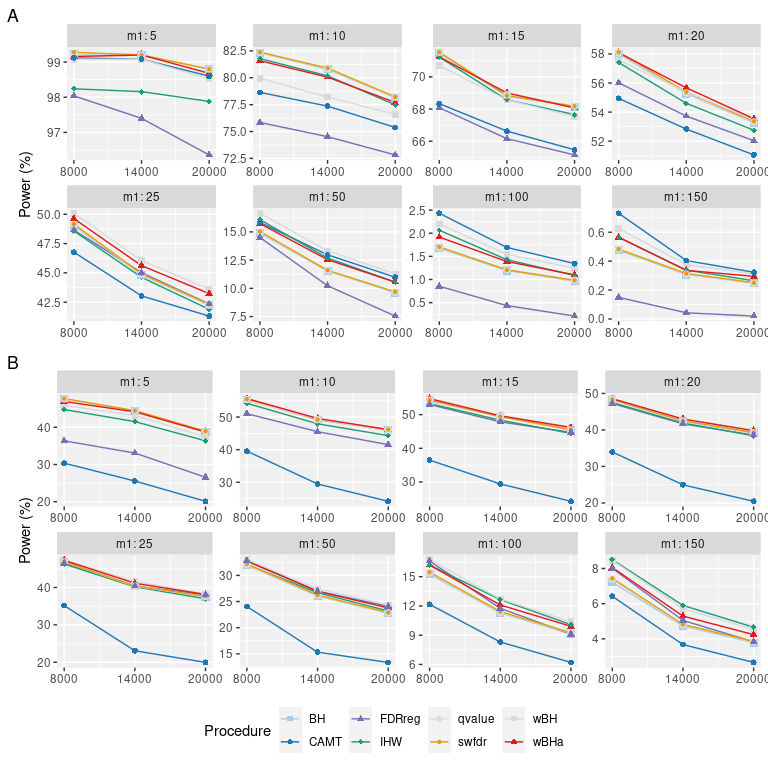

```r
graph_power_ind$reference
```

#### Power of rare causal variant

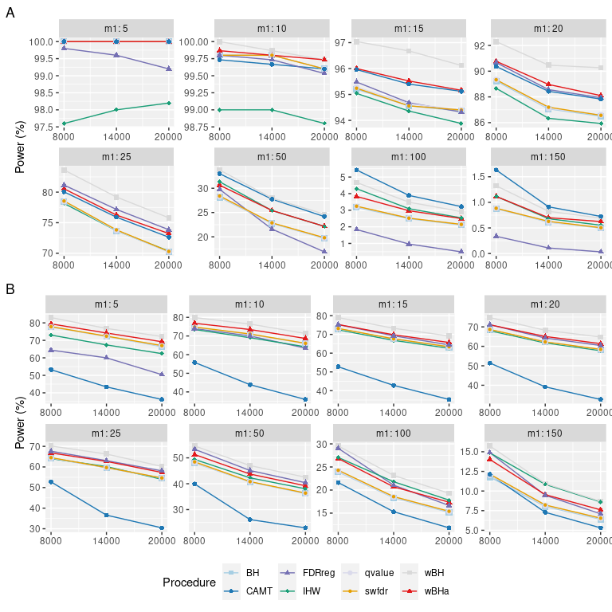

```r
graph_power_rare_ind$reference
```

#### FDR

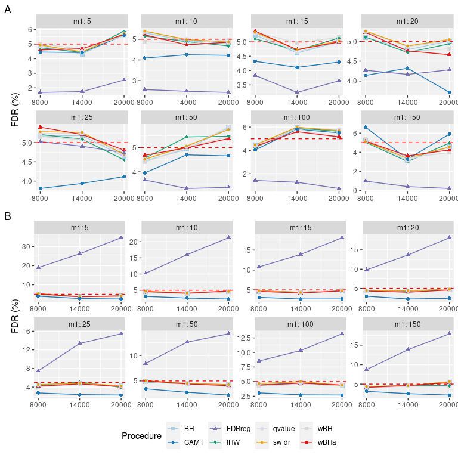

```r
graph_FDR_ind$reference
```

### Inverse Scenario (Scenario 2)

#### Overall power

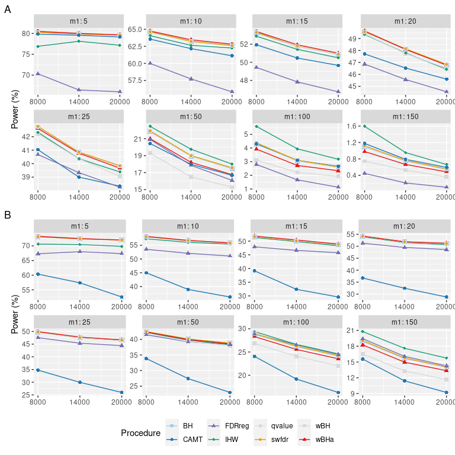

```r
graph_power_ind$inverse
```

#### Power of rare causal variant

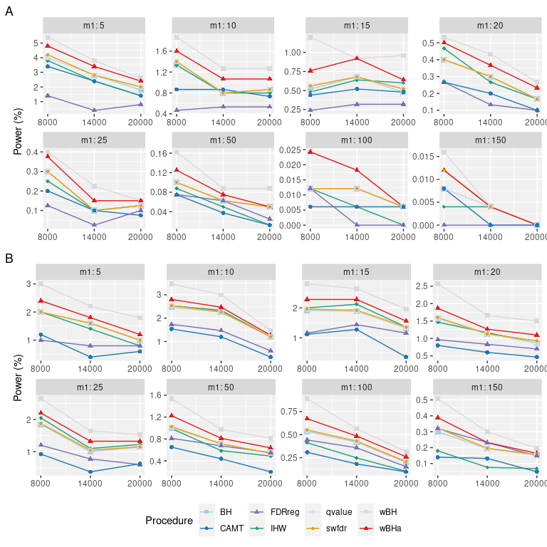

```r
graph_power_rare_ind$inverse
```

#### FDR

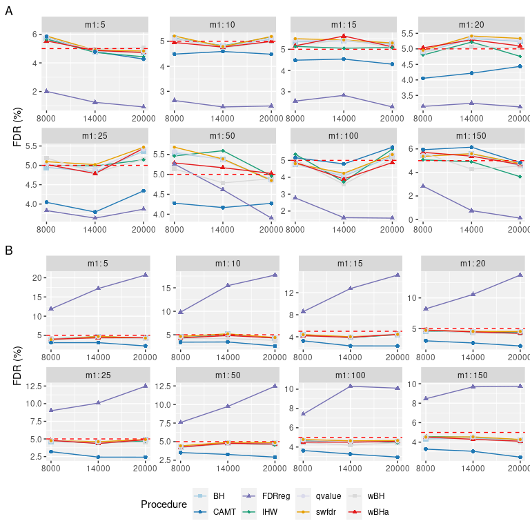

```r
graph_FDR_ind$inverse
```

### Constant Scenario (Scenario 3)

#### Overall power

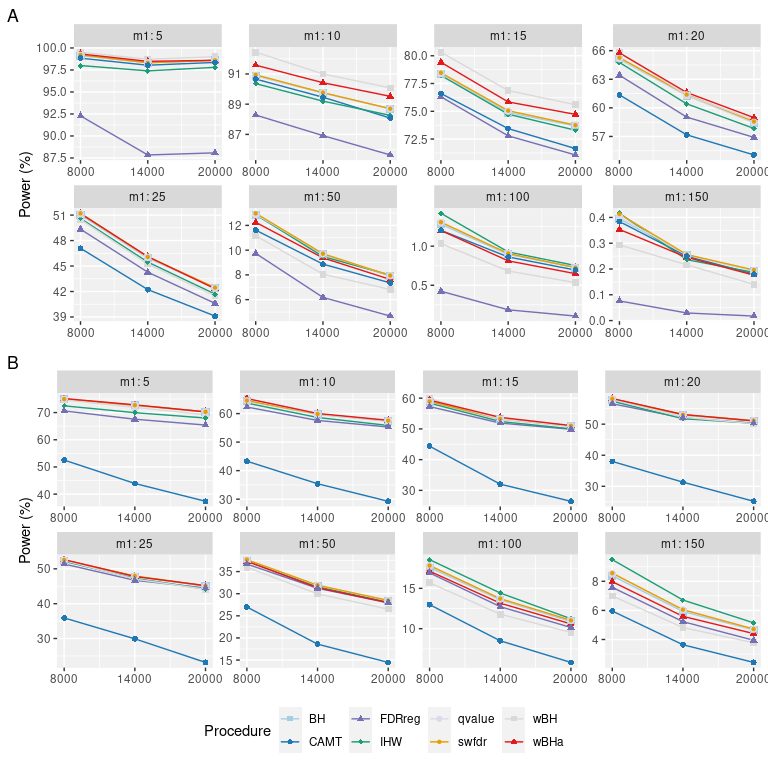

```r
graph_power_ind$constant
```

#### Power of rare causal variant

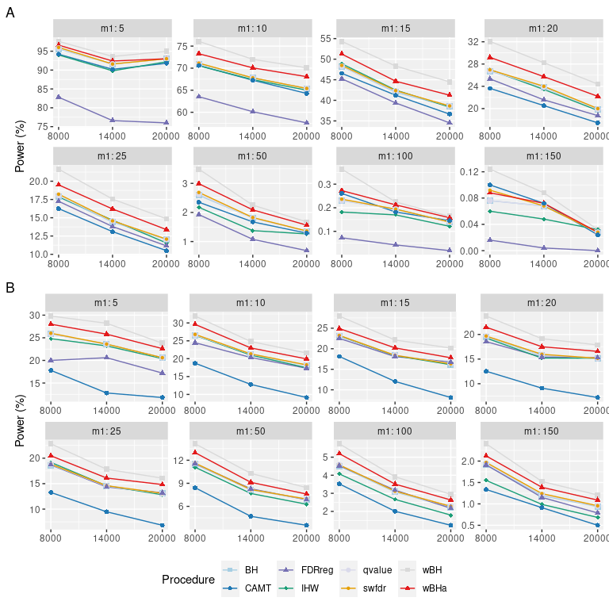

```r
graph_power_rare_ind$constant
```

#### FDR

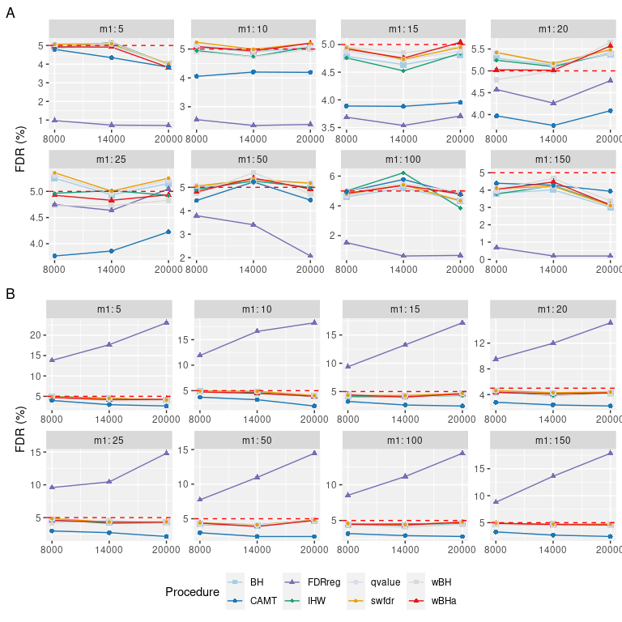

```r
graph_FDR_ind$constant
```

## Correlation Case

### Reference Scenario (Scenario 1)

#### Overall power

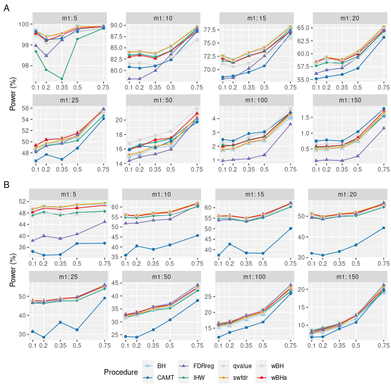

```r
graph_power_corr$reference
```

#### Power of rare causal variant

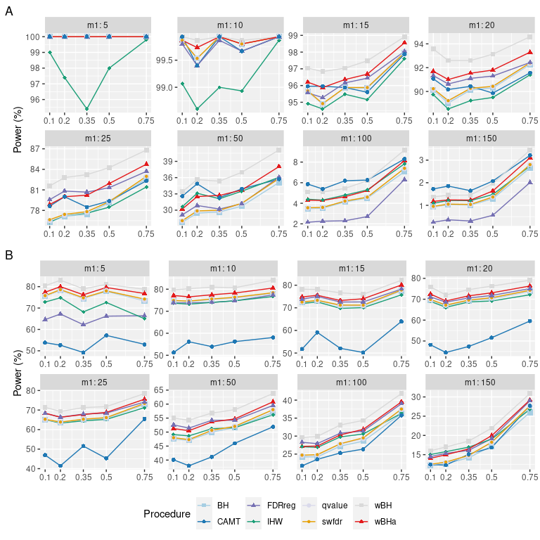

```r
graph_power_rare_corr$reference
```

#### FDR

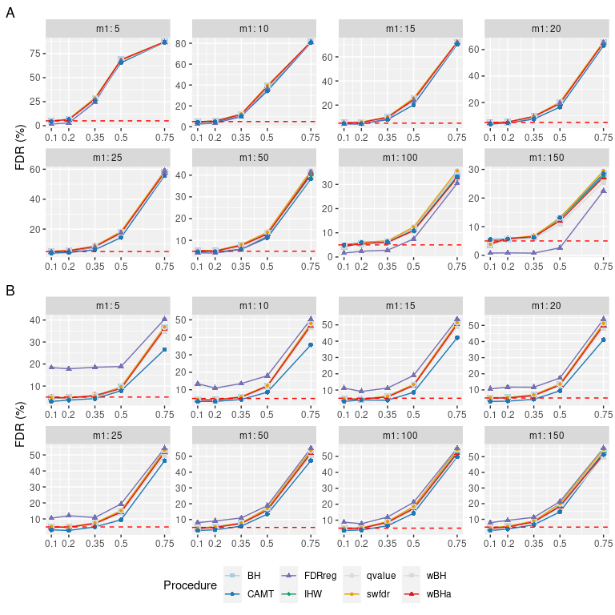

```r
graph_FDR_corr$reference
```

### Inverse Scenario (Scenario 2)

#### Overall power

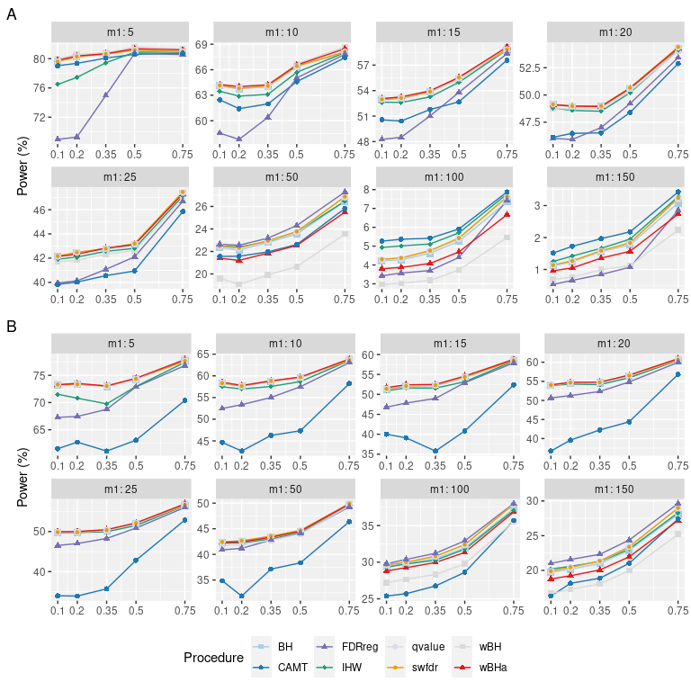

```r
graph_power_corr$inverse
```

#### Power of rare causal variant

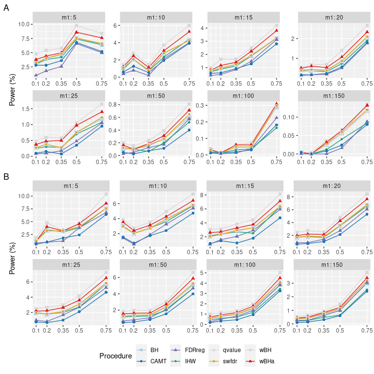

```r
graph_power_rare_corr$inverse
```

#### FDR

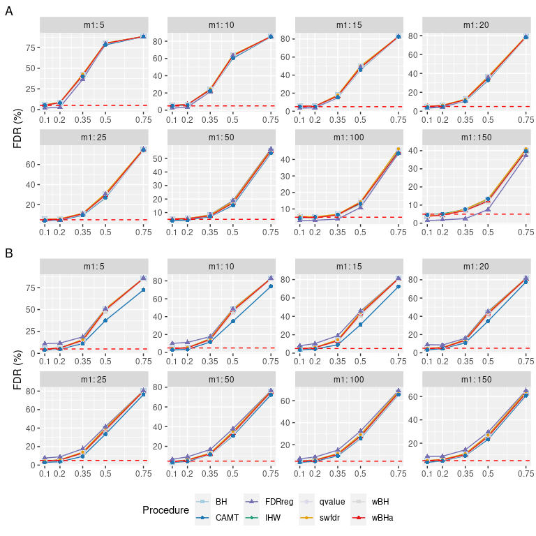

```r
graph_FDR_corr$inverse
```

### Constant Scenario (Scenario 3)

#### Overall power

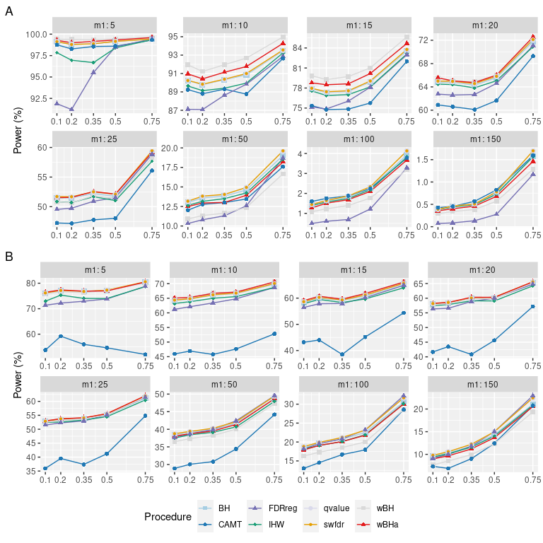

```r
graph_power_corr$constant
```

#### Power of rare causal variant

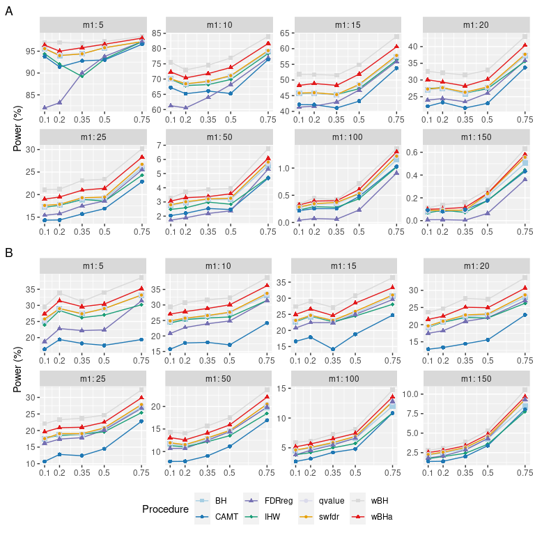

```r
graph_power_rare_corr$constant
```

#### FDR

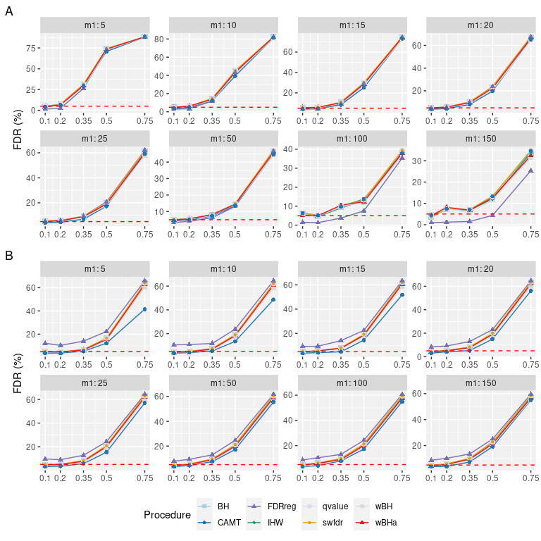

```r
graph_FDR_corr$constant
```

## Simulations based on real dataset Case

#### Overall power

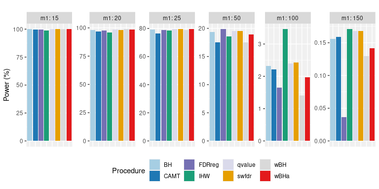

```r
graph_power_semisimu
```

#### Power of rare causal variant

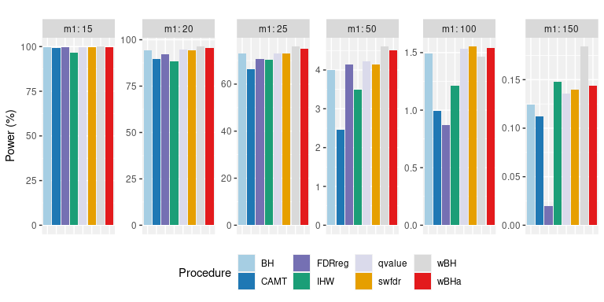

```r
graph_power_rare_semisimu
```

#### FDR

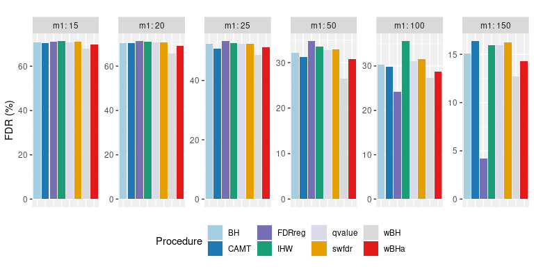

```r
graph_FDR_semisimu
```